# Analysis of Crime Data from 2010 to Present to Predict Crime Committed

Chanel Aquino, Dario Molina, Evert Rodriguez

May 7, 2018

## Introduction / Objective

In this project, we will utilize, visualize, and analyze data from the [Crime Data from 2010 to Present](https://data.lacity.org/A-Safe-City/Crime-Data-from-2010-to-Present/y8tr-7khq) dataset. The dataset reflects incidents of crime in the City of Los Angeles dating back to 2010. Before any preprocessing, there are approximately 1.73 million rows and 26 columns in the dataset; each row represents a crime incident.

After some initial data observation, we will finally create some classification learning models to predict what crime will be committed given certain predictors.

## Data

```r
> library(rpart)
```

```r
> library(rpart.plot)
> library(maptree)
> library(caret)
> source("https://raw.githubusercontent.com/grbruns/cst383/master/lin-regr-util.R")
> source("https://raw.githubusercontent.com/grbruns/cst383/master/class-util.R")
> #crimes = read.csv('~/crime-predictor/crimes.csv', na.strings=c('NA', 'N/A', '<NA>'))
> crimes <- read.csv('crimes.csv',na.strings=c('NA', 'N/A', '<NA>'))
> names(crimes) = tolower(names(crimes))
```

## Preprocessing / Cleaning

The following is a table of columns that were removed from the dataset and the reasons why they were removed.

| column removed | description of column | reason for removing |
| --- | --- | --- |
| dr.number | the division records number | merely uniquely IDs each row; does not provide valuable information |
| area.id | ID of community police station | will use **area.name** column for area |
| reporting.district | 4-digit code that represents a sub-area within a Geographic Area | will use **location** column for locating crimes |
| mo.code | modus operandi: activities associated with the suspect in commission of the crime | would be time consuming to translate these to their descriptions |
| crime.code | indicates the crime committed | will use **crime.code.description** to describe crime committed |
| crime.code.1 | same as crime.code | (same as above) |
| crime.code.2 | code for any additional crime | crime codes 2, 3, and 4 are respectively less serious offenses |
| crime.code.3 | code for any additional crime | (same as above) |
| crime.code.4 | code for any additional crime | (same as above) |
| premise.code | code for the type of structure, vehicle, or location where the crime took place | will use **premise.description** to describe premise |
| weapon.used.code | code for the type of weapon used | will use **weapon.description** to describe weapon |
| status.code | status of the case | status of the case irrelevant to predicting crime committed |
| status.description | defines the status code provided | (same as above) |
| address | street address of crime incident rounded to the nearest hundred block to maintain anonymity | will use **location** column for locating crimes |
| cross.street | cross street of rounded address | (same as above) |

```r
> crimes[['dr.number']] = NULL
> crimes[['area.id']] = NULL
> crimes[['reporting.district']] = NULL
> crimes[['mo.codes']] = NULL
> crimes[['crime.code']] = NULL
> crimes[['crime.code.1']] = NULL
> crimes[['crime.code.2']] = NULL
> crimes[['crime.code.3']] = NULL
> crimes[['crime.code.4']] = NULL
> crimes[['premise.code']] = NULL
> crimes[['weapon.used.code']] = NULL
> crimes[['status.code']] = NULL
> crimes[['status.description']] = NULL
> crimes[['address']] = NULL
> crimes[['cross.street']] = NULL
```

## Missing Data

After removing unneeded columns, we calculated the percentages of NA values in each column in the dataset. (If there are no NA values in the column, this information was not displayed.) 8% of the rows in the dataset did not have values for the **victim.age** column. These rows were omitted from the dataset.

```r
> pct.na = apply(crimes, 2, function(x) round(mean(is.na(x)) * 100, 3))
> pct.na = pct.na[pct.na > 0]
> data.frame(pct.na)
```

```
           pct.na
victim.age  8.017
```

```r
> crimes = na.omit(crimes)
```

## Preprocessing (continued): month, day, year, and hour

Here, **month**, **day**, **year**, and **hour** columns were created after being derived from the **date.occurred** and **time.occurred** columns. These new columns represent the date and time that the crime occurred. Finally, crimes that occurred during the years 2010 - 2013 (inclusive) will be removed from the dataset, resulting in a dataset with crimes occurring in the past 5 years only.

```r
> crimes$month = as.numeric(substr(crimes$date.occurred,1,2))
> crimes$day = as.numeric(substr(crimes$date.occurred,4,5))
> crimes$year = as.numeric(substr(crimes$date.occurred,7,10))
> years = c(2014:2018)
> crimes = crimes[crimes$year %in% years,]
>
> crimes$hour = NA
> rows = which(nchar(crimes$time.occurred) == 1)
> crimes$hour[rows] = 0
>
> rows = which(nchar(crimes$time.occurred) == 2)
> crimes$hour[rows] = 0
>
> rows = which(nchar(crimes$time.occurred) == 3)
> crimes$hour[rows] = as.numeric(substr(crimes$time.occurred[rows],1,1))
>
> rows = which(nchar(crimes$time.occurred) == 4)
> crimes$hour[rows] = as.numeric(substr(crimes$time.occurred[rows],1,2))
>
> crimes[['date.reported']] = NULL
> crimes[['date.occurred']] = NULL
> crimes[['time.occurred']] = NULL
```

## Preprocessing (continued): Categorizing crime.code.description, weapon.code.description, and victim.descent

Currently, there are 143 unique values in the **crime.code.description**. In an effort to simplify classification, values in this column will be categorized into 1 of 4 groups: i) violent crime, ii) property crime, iii) consensual crime, and iv) other (which contains white-collar crimes, organized crimes, and consensual crimes. Descriptions and examples of these different types of crime can be found in the online text, [Social Problems: Continuity and Change](https://saylordotorg.github.io/text_social-problems-continuity-and-change/s11-02-types-of-crime.html). It is important to note that we lose some valuable information when condensing 143 crime descriptions into 4 categories.

```r
> crimes$crime.code.description = tolower(crimes$crime.code.description)
> crimes$crime.type = NA
>
> # violent crime
> patterns = c('assault', 'neglect', 'firearms', 'rape', 'sex', 'abuse',
+              'shots', 'bomb', 'kidnap', 'lynch', 'battery', 'reckless driving',
+              'abandonement', 'drugs', 'manslaughter', 'trafficking', 'abortion',
+              'weapon', 'cruelty', 'child', 'false imprisonment', 'threats', 'chld',
+              'homicide', 'oral copulation', 'incest', 'firearms restraining order' )
> crimes$crime.type[grepl(paste(patterns, collapse = "|"), crimes$crime.code.description)] = "violent"
>
> # property crime
> patterns = c('burglary', 'theft', 'shoplifting', 'stolen', 'arson',
+              'vandalism', 'defrauding innkeeper', 'disrupt school',
+              'pickpocket', 'train wrecking', 'robbery', 'theft of identity',
+              'tresspassing', 'document forgery / stolen felony', 'rob', 'prowler',
+              'stalking', 'peeping tom', 'unauthorized computer access',
+              'disturbing the peace', 'failure to disperse', 'fraud',
+              'throwing object at moving vehicle', 'property', 'snatching', 'till tap')
> crimes$crime.type[grepl(paste(patterns, collapse = "|"), crimes$crime.code.description)] = "property"
>
>
> # consensual crime
> patterns = c('pimping', 'resisting', 'indecent exposure', 'contempt of court',
+              'violation of temporary restraining order', 'failure to yield',
+              'violation of restraining order', 'driving without owner consent', 'document worthless',
+              'bribery', 'pandering', 'extortion', 'counterfeit')
> crimes$crime.type[grepl(paste(patterns, collapse = "|"), crimes$crime.code.description)] = "consensual"
>
> # other crime
> crimes$crime.type[is.na(crimes$crime.type)] = "other"
>
> crimes$crime.type = factor(crimes$crime.type)
> crimes[['crime.code.description']] = NULL
```

Similary, the 79 unique values in the **weapon.description** column were used to create a new column, **weapon.type** that contains 1 of 4 values: i) projectile, ii) edged, iii) impact, and iv) other (which includes chemical weapons and weapons of mass destruction). Details on these types of weapons can be found on the [Black Belt](https://blackbeltmag.com/martial-arts-weapons/5-categories-of-modern-weapons-how-to-incorporate-them-into-your-reality-based-self-defense-training/) website. Again, it is important to note that we lose some valuable information when condensing 79 weapon descriptions into 4 categories.

```r
> crimes$weapon.description = tolower(crimes$weapon.description)
> crimes$weapon.type = NA
>
> # projectile weapons
> patterns = c('bottle', 'pistol', 'gun', 'revolver', 'rifle',
+              'bow and arrow', 'semiautomatic assault', 'firearm',
+              'rock', 'thrown')
> crimes$weapon.type[grepl(paste(patterns, collapse = "|"), crimes$weapon.description)] = "projectile"
>
> # edged weapons
> patterns = c('knife', 'screwdriver', 'switchblade', 'cutting',
+              'dagger', 'razor', 'glass', 'ice pick', 'machete',
+              'sword', 'cleaver', 'scissors', 'axe')
> crimes$weapon.type[grepl(paste(patterns, collapse = "|"), crimes$weapon.description)] = "edged"
>
> # impact weapons
> patterns = c('belt flailing instrument/chain', 'hammer', 'club/bat',
+              'martial arts weapons', 'brass knuckles', 'syringe', 'rope',
+              'strong-arm', 'stick', 'pipe', 'board', 'fixed object',
+              'concrete block', 'tire iron', 'blackjack')
> crimes$weapon.type[grepl(paste(patterns, collapse = "|"), crimes$weapon.description)] = "impact"
>
> # other weapons
> crimes$weapon.type[is.na(crimes$weapon.type)] = "other"
>
> crimes$weapon.type = factor(crimes$weapon.type)
> crimes[['weapon.description']] = NULL
```

Finally, the **victim.descent** column was altered to contain the following values: asian, black, hispanic/latin, american indian/native, pacific islander, white, other/unknown. The **victim.sex** column was also altered to contain the following values: male, female, and other/unknown.

```r
> crimes$victim.descent = tolower(crimes$victim.descent)
> crimes$victim.descent[crimes$victim.descent == 'a'] = 'asian'
> crimes$victim.descent[crimes$victim.descent == 'c'] = 'asian'
> crimes$victim.descent[crimes$victim.descent == 'd'] = 'asian'
> crimes$victim.descent[crimes$victim.descent == 'f'] = 'asian'
> crimes$victim.descent[crimes$victim.descent == 'j'] = 'asian'
> crimes$victim.descent[crimes$victim.descent == 'k'] = 'asian'
> crimes$victim.descent[crimes$victim.descent == 'l'] = 'asian'
> crimes$victim.descent[crimes$victim.descent == 'v'] = 'asian'
> crimes$victim.descent[crimes$victim.descent == 'z'] = 'asian'
>
> crimes$victim.descent[crimes$victim.descent == 'b'] = 'black'
>
> crimes$victim.descent[crimes$victim.descent == 'h'] = 'hispanic/latin'
>
> crimes$victim.descent[crimes$victim.descent == 'i'] = 'american indian/native'
>
> crimes$victim.descent[crimes$victim.descent == 'g'] = 'pacific islander'
> crimes$victim.descent[crimes$victim.descent == 'p'] = 'pacific islander'
> crimes$victim.descent[crimes$victim.descent == 's'] = 'pacific islander'
> crimes$victim.descent[crimes$victim.descent == 'u'] = 'pacific islander'
>
> crimes$victim.descent[crimes$victim.descent == 'w'] = 'white'
>
> crimes$victim.descent[crimes$victim.descent == 'o'] = 'other/unknown'
> crimes$victim.descent[crimes$victim.descent == ''] = 'other/unknown'
> crimes$victim.descent[crimes$victim.descent == 'x'] = 'other/unknown'
>
> crimes$victim.descent = factor(crimes$victim.descent)
>
> crimes$victim.sex = tolower(crimes$victim.sex)
> crimes$victim.sex[crimes$victim.sex == 'm'] = 'male'
> crimes$victim.sex[crimes$victim.sex == 'f'] = 'female'
> crimes$victim.sex[crimes$victim.sex == 'x'] = 'other/unknown'
> crimes$victim.sex[crimes$victim.sex == 'h'] = 'other/unknown'
> crimes$victim.sex[crimes$victim.sex == ''] = 'other/unknown'
> crimes$victim.sex = factor(crimes$victim.sex)
```

## Data Exploration

The boxplot below shows the age distribution of victims by their descent. For instance, victims of American Indian/Native descent were, on average, about 24-25 years old. Victims of Asian descent were, on average, about 40 years old.

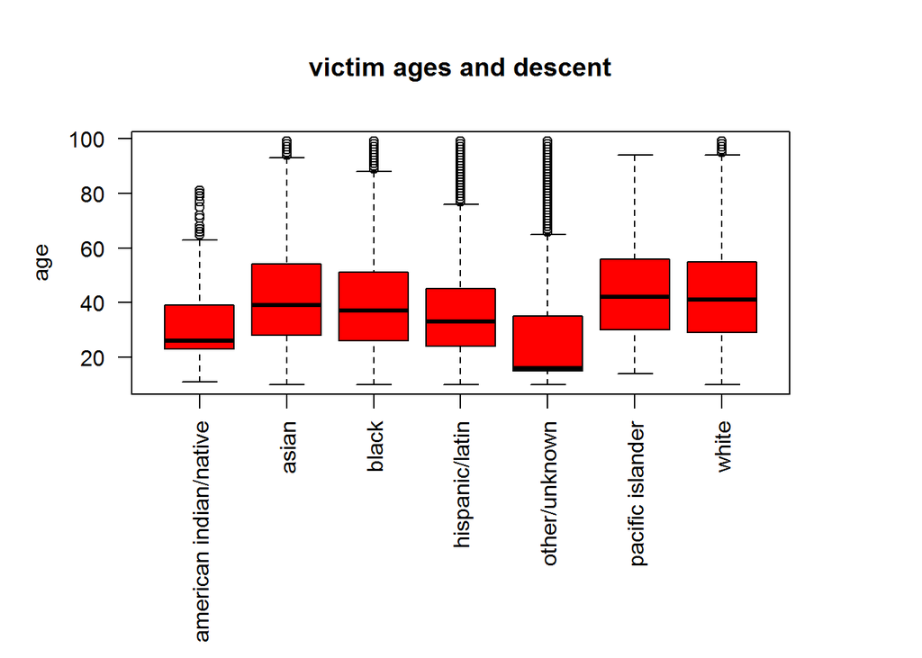

```r
> par(mar=c(10,5,5,5))
> boxplot(victim.age ~ victim.descent, data=crimes, main='victim ages and descent', las=2, ylab='age', col='red')
```

The barplot belows shows the frequency distribution of crimes committed by the hour. Less crimes were committed during the hours between 4 and 5 (i.e., 4am and 5am). It is interesting to note the visual anomaly at hour 12 (i.e., 12pm), when most crimes were commited.

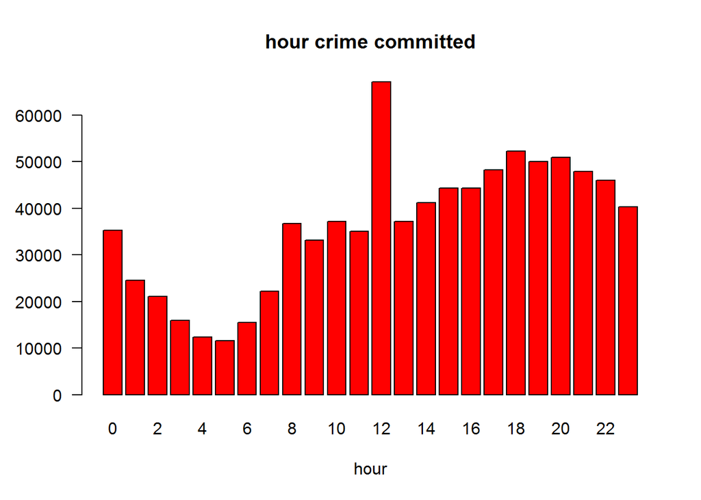

```r
> barplot(table(crimes$hour), main='hour crime committed', xlab='hour', col='red', las=1)
```

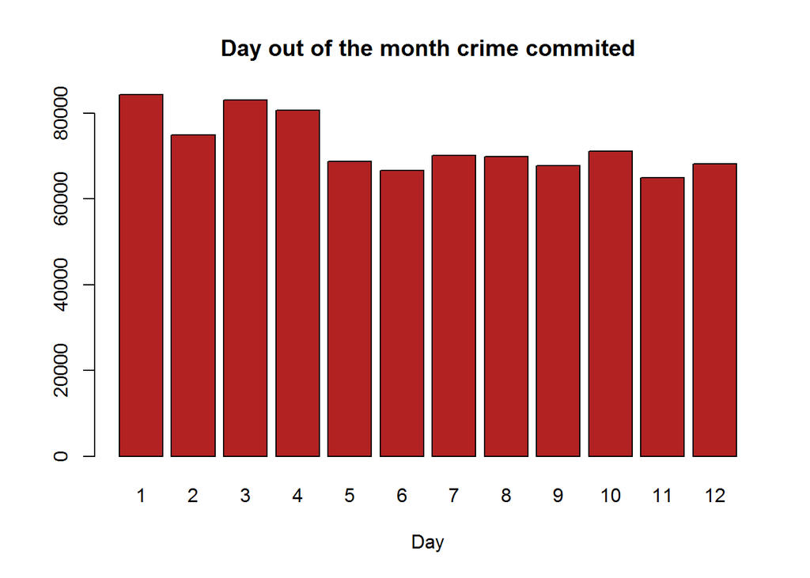

```r
> barplot(table(crimes$month), main="Day out of the month crime commited", xlab="Day",col="firebrick")
```

The quadruple density plot below further breaks down crimes by the hour, by the type of crime it was. Overall, the plots below follow the same pattern as the barplot above. Again, we see a significant increase in crimes committed during the afternoon. The plot for property crimes shows a very interesting pattern than noticeably fluctuates in between the hours of about 13 and 22 (i.e., 1pm and 10pm).

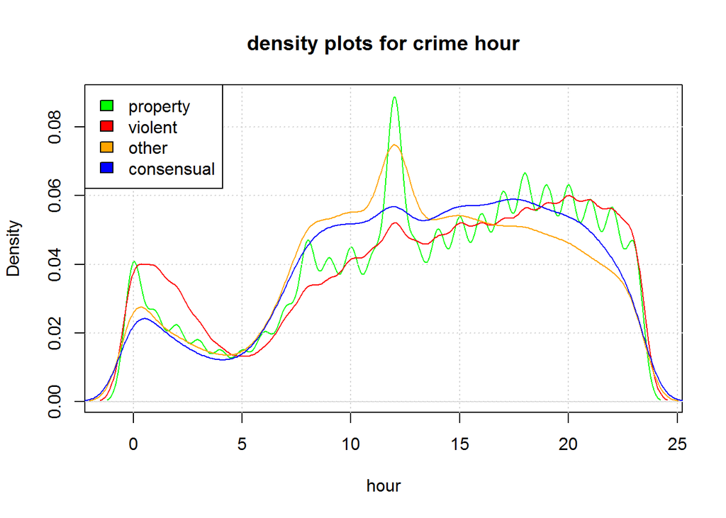

```r
> # quadruple density plot for hour
> plot(density(crimes$hour[crimes$crime.type == 'property']), main='density plots for crime hour', col='green', xlab='hour')
> grid()
> lines(density(crimes$hour[crimes$crime.type == 'violent']), col='red')
> lines(density(crimes$hour[crimes$crime.type == 'other']), col='orange')
> lines(density(crimes$hour[crimes$crime.type == 'consensual']), col='blue')
> legend('topleft', fill=c('green', 'red', 'orange', 'blue'), legend=c('property', 'violent', 'other', 'consensual'))
```

### Victim sex based on crime type

The following plot will depict which sex is more susceptible to the different types of crimes.

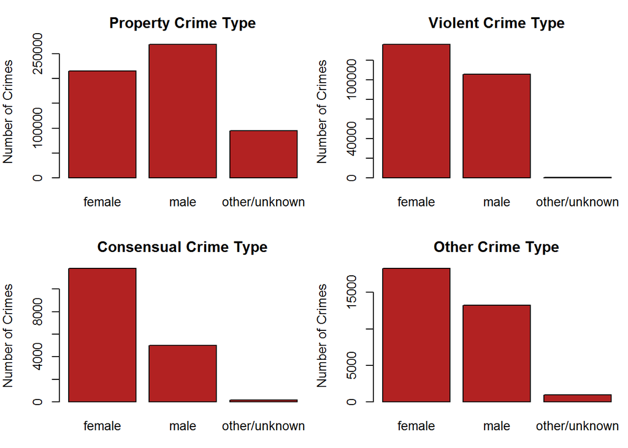

```r
> par(mfrow=c(2,2))
> par(mar=c(3,4,3,.5))
> plot(crimes$victim.sex[crimes$crime.type == "property"], main="Property Crime Type", col="firebrick",ylab="Number of Crimes")
> plot(crimes$victim.sex[crimes$crime.type == "violent"], main="Violent Crime Type",col="firebrick",ylab="Number of Crimes")
> plot(crimes$victim.sex[crimes$crime.type == "consensual"],main="Consensual Crime Type",col="firebrick",ylab="Number of Crimes")
> plot(crimes$victim.sex[crimes$crime.type == "other"], main="Other Crime Type",col="firebrick",ylab="Number of Crimes")
```

From the graphs, it is evident to see that for property crimes, males were afflicted the most. But for the the rest of the different crime types, women were afflicted the most. Which in overall, women are more susceptible to most crimes compared to the other sexes.

## Classification Tree Model

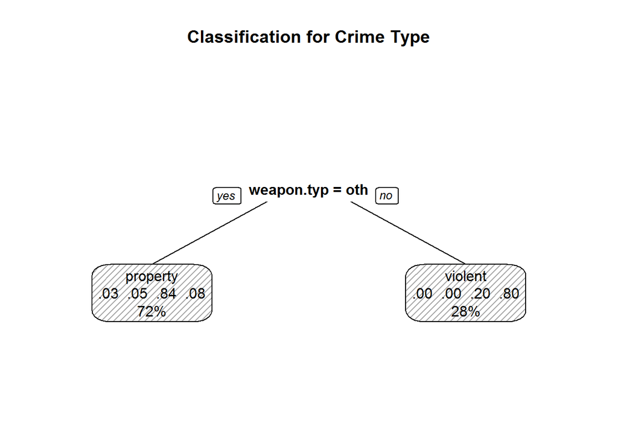

```r
> # TODO: dario + assessment
> set.seed(132)
> crimes.small = crimes[crimes$year %in% c(2016,2017),]
> tr.rows = sample(1:nrow(crimes), .75*nrow(crimes))
> tr_dat = crimes[tr.rows,]
> te_dat = crimes[-tr.rows,]
>
> treeFit = rpart(crime.type ~  month + victim.sex+ victim.age + weapon.type  ,data=tr_dat, method="class")
>
> prp(treeFit, extra=104, varlen=-10,
+  main="Classification for Crime Type",
+  box.col=c("palegreen", "pink")[treeFit$frame$yval])
```

As we can see from the model above, the classification tree is only displaying two nodes. From the information obtained from the fit, it was evident that the most important variable type was weapon.type(99) and the second most important variable was victim.age(1). Which is why on the classification tree weapon.type is the only visible predictor shown.

From the confusion matrix, it is evident that there was no prediction made for consensual and other.

```r
> predicted = predict(treeFit, te_dat, type="class")
> actuals = te_dat$crime.type
> conf = table(predicted, actuals)
> conf
```

```
            actuals
predicted    consensual  other property violent
  consensual          0      0        0       0
  other               0      0        0       0
  property         3914   7918   133100   13194
  violent           241    196    11765   47377
```

It can also be noted that the accuracy of our model is about 82%, which is quite good.

```r
>  x =table(as.data.frame(predicted))
>  succ_rate = mean(predicted == actuals)
>  round(succ_rate, 3)
```

```
[1] 0.829
```

From the values obtained from the predictions obtained from the tree classification, it was interesting to notice the total number of crimes for each category.

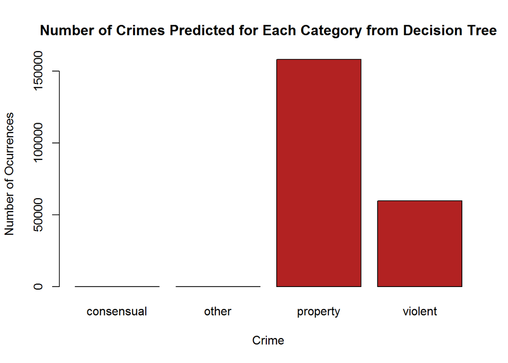

```r
> y = as.data.frame(predicted)
> options(scipen=5)
> plot(y, main="Number of Crimes Predicted for Each Category from Decision Tree", xlab="Crime",ylab="Number of Ocurrences", col="firebrick")
```

Another interesting to note is the purity of node from the classification tree.

```r
> # compute Gini index for a node (factor of 2 not used)
> gini_index = function(v) {
+   tbl = table(v)
+   probs = tbl/sum(tbl)
+   terms = sapply(probs, function(p) p * (1 - p))
+   return(sum(terms))
+ }
> node = crimes[,c("crime.type","victim.age","victim.sex","weapon.type")]
> node.purity = gini_index(node$crime.type)
> node.purity
```

```
[1] 0.4793042
```

From the classification tree, using month, victim.sex, victim.age, weapon.type as predictors, it is predicted that the crime type is Property.

```r
> table(crimes$crime.type)/nrow(crimes)
```

```
consensual      other   property    violent
0.01953793 0.03727870 0.66411045 0.27907292
```

When comparing the training results, it can be seen that the probablity of property is bigger than the rest. Which correlates to the predictions from classification which predicted crime type to be property.

## Naive Bayes Classification Model 1

For this first model, we decided to use area.name and weapon.type to predict the crime.type . Even though our classification tree model had a good acuracy, wanted to see if using Naive Baye’s algorithm would improve our results.

## Splitting Data

Below, training and testing sets are created, where the training set is composed of 75% of the original dataset.

```r
> set.seed(123)
> tr.rows = sample(1:nrow(crimes), .75*nrow(crimes))
> tr.dat = crimes[tr.rows,]
> te.dat = crimes[-tr.rows,]
```

## Creating Model and Generating Predictions

```r
> library(e1071)
> # TODO: evert + assessment
>
> #Creating model
> nb.fit1 = naiveBayes(crime.type ~ area.name + weapon.type, data=tr.dat, type='raw')
>
> #Predictions & Accuracy
> predicted = predict(nb.fit1, te.dat)
> actual = te.dat$crime.type
> paste("acurracy:",mean(predicted == actual))
```

```
[1] "acurracy: 0.828860154796628"
```

```r
> table(actual, predicted)
```

```
            predicted
actual       consensual  other property violent
  consensual          0      0     4071     239
  other               0      0     7867     207
  property            0      0   132729   11689
  violent             0      0    13185   47718
```

Here we have our first Naive Baye’s model and the predicitons it generated on our test data.

### Frequency of type.crime in test data and predictions

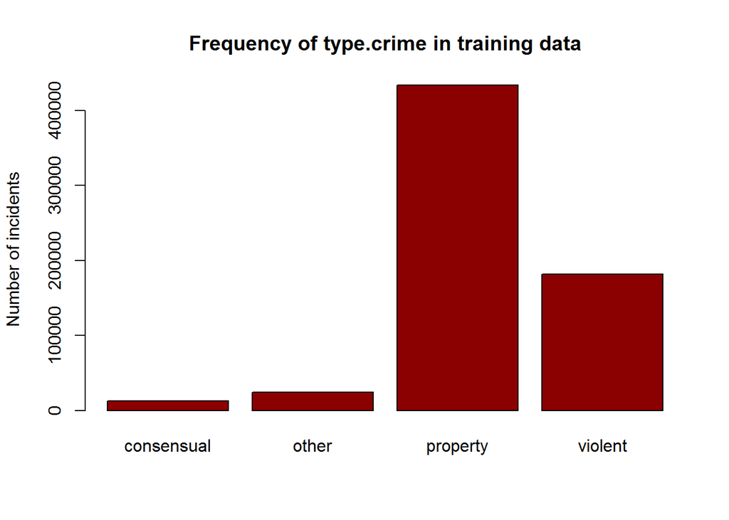

```r
> barplot(table(tr.dat$crime.type),col = "red4", main="Frequency of type.crime in training data",ylab="Number of incidents")
```

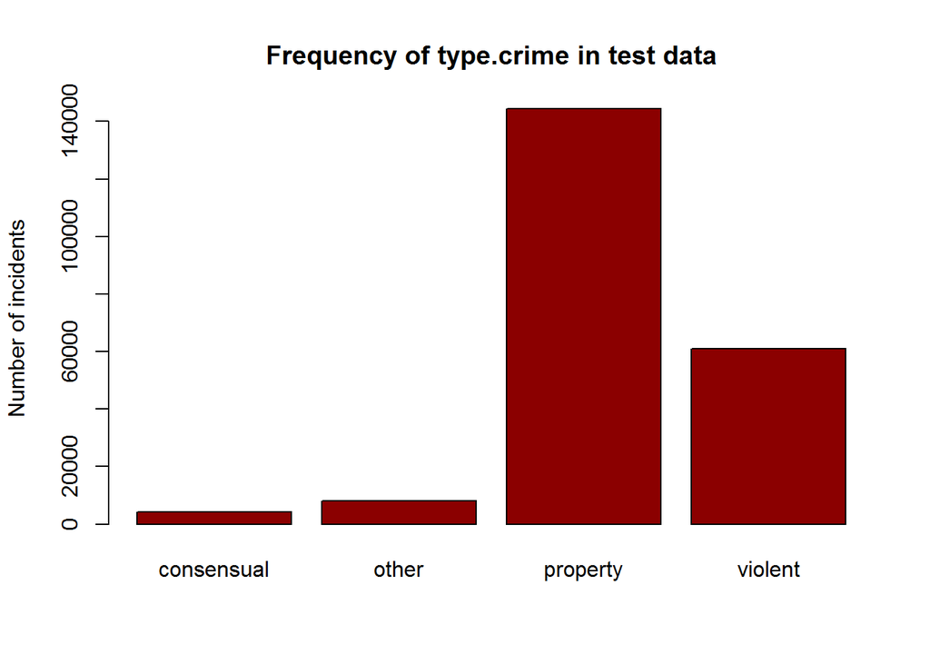

```r
> barplot(table(te.dat$crime.type),col = "red4", main="Frequency of type.crime in test data",ylab="Number of incidents")
```

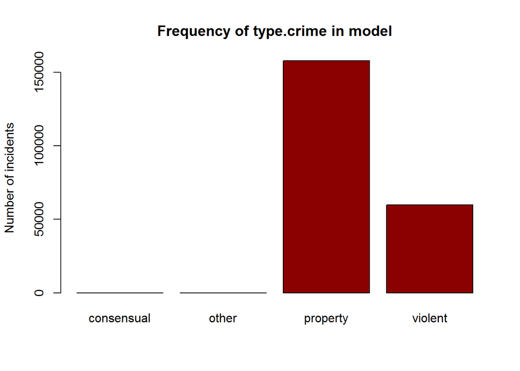

```r
> plot(predicted,col = "red4", main="Frequency of type.crime in model",ylab="Number of incidents")
```

These graphs help us understand our model a little bit better. Since the majority of the types of crime commited fall into either the “violent” class or the “property” class in our traning data, it seems like our model is only predicting from these two classes. Despite this, it is still achiving a decent accuracy. A learning curve was produced to see if our modle had high variance or bias.

### Learning Curve for NB Model 1

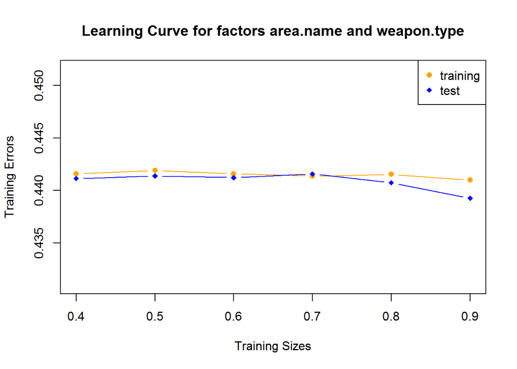

```r
> te_errs = c()
> tr_errs = c()
> te_actual = te_dat$crime.type
> tr_sizes = seq(0.4,0.9, by = 0.1)
>
> for (tr_size in tr_sizes) {
+   tr_rows=sample(1:nrow(crimes),tr_size*nrow(crimes))
+   tr_dat=crimes[tr_rows,]
+   te_dat=crimes[-tr_rows,]
+   tr_actual = tr_dat$crime.type
+   nb.fit1.lc = naiveBayes(crime.type ~ area.name + weapon.type, data=tr_dat, type='raw')
+
+
+   # error on training set
+    tr_predicted = predict(nb.fit1.lc, newdata=te_dat, type="class")
+    err = mean(tr_actual != tr_predicted)
+    tr_errs = c(tr_errs, err)
+
+    # error on test set
+   te_predicted = predict(nb.fit1.lc, newdata=te_dat, type="class")
+   err = mean(te_actual != te_predicted)
+   te_errs = c(te_errs, err)
+ }
>
> #Plot learning curve here
> plot(tr_errs~tr_sizes,col="orange",type="b",pch=16,ylim=c(min(tr_errs)-.01,max(te_errs)+0.01),xlab="Training Sizes", ylab="Training Errors",main="Learning Curve for factors area.name and weapon.type")
> points(te_errs~tr_sizes,col="blue",type="b",pch=18,ylim=c(min(tr_errs)-.01,max(te_errs)+0.01))
> legend("topright",legend=c("training","test"), col=c("orange","blue"),pch=c(16,18))
```

After analyzing several learning curves on our model, we generally see that traning error and testing error are quite similar and consistent, with testing error decreasing slightly at the end. By the shape of the graph, we can also see that our model has some bias. To fix this issue we can me more careful about the predictors that we use.

## Naive Bayes Classification Model 2: victim.descent, and victim.age

A second Naive Bayes classification model was created, this time using **victim.descent** and **victim.age** to predict **crime.type**. From the apriori of the model, we can see that property crimes were the highest types of crime committed.

```r
> # TODO: chanel + assessment
> nb.fit2 = naiveBayes(crime.type ~ victim.descent + victim.age, data=tr.dat, type='raw')
> nb.fit2$apriori
```

```
Y
consensual      other   property    violent
     12704      24389     433902     182119
```

The accuracy of this fit is below.

```r
> predicted = predict(nb.fit2, te.dat)
> actual = te.dat$crime.type
> mean(predicted == actual)
```

```
[1] 0.6604901
```

A confusion matrix is below to help give a more detailed perspective of how well this model performed.

```r
> table(actual, predicted)
```

```
            predicted
actual       consensual  other property violent
  consensual          0      0     4100     210
  other               0      0     7614     460
  property            0      0   138971    5447
  violent             0      0    56082    4821
```

Below are mean and standard deviation values for victim ages categorized by the crime type.

```r
> nb.age.info = nb.fit2$tables$victim.age
> nb.age.info
```

```
            victim.age
Y                [,1]     [,2]
  consensual 38.56400 15.66599
  other      37.86338 16.37752
  property   36.45758 17.56909
  violent    35.11487 14.86588
```

### Feature Distribution for NB Model 2

Using the tables provided in the fit, we can show the feature distributions below.

The first pair of graphs show the density distribution of victims’ ages both from the training dataset (right) and as estimates from the Naive Bayes fit (left).

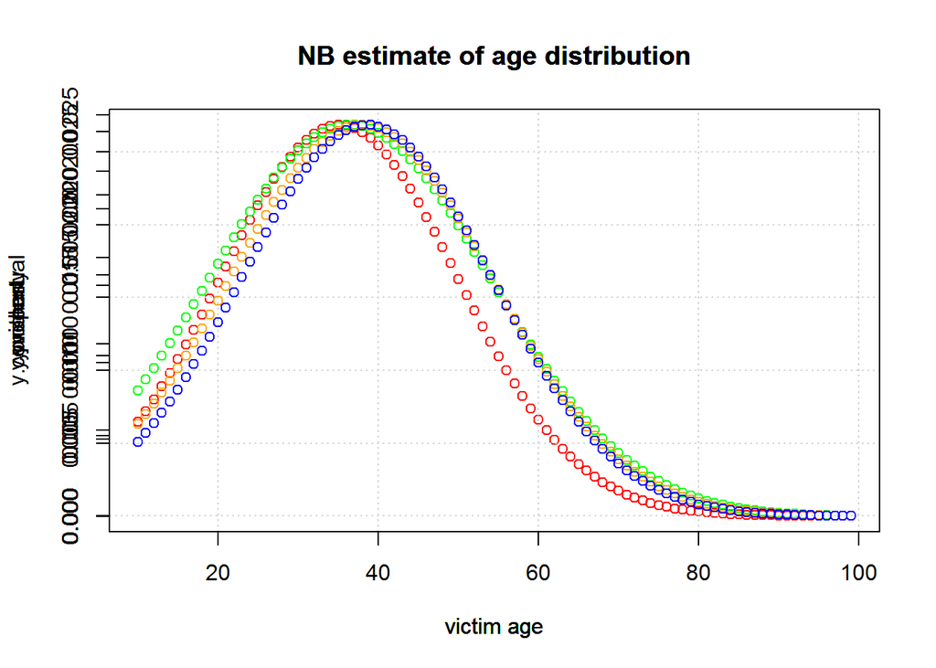

```r
> # density plot for victim.age, from naive bayes
> x = crimes$victim.age
> y.property = dnorm(x, mean=nb.age.info['property',1], sd=nb.age.info['property',2])
> y.violent = dnorm(x, mean=nb.age.info['violent',1], sd=nb.age.info['violent',2])
> y.other = dnorm(x, mean=nb.age.info['other',1], sd=nb.age.info['other',2])
> y.consensual = dnorm(x, mean=nb.age.info['consensual',1], sd=nb.age.info['consensual',2])
>
> plot(x, y.violent, main='NB estimate of age distribution', col='red', xlab='victim age')
> grid()
> par(new=T)
> plot(x, y.property, col='green', main='NB estimate of age distribution', xlab='victim age', xaxt='n')
> par(new=T)
> plot(x, y.other, col='orange', main='NB estimate of age distribution', xlab='victim age', xaxt='n')
> par(new=T)
> plot(x, y.consensual, col='blue', main='NB estimate of age distribution', xlab='victim age', xaxt='n')
```

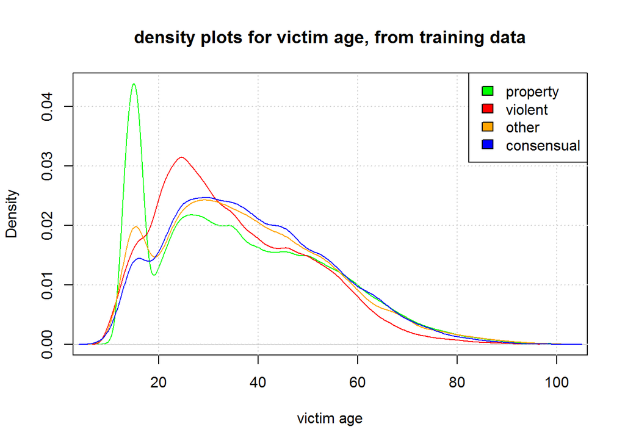

```r
> # quadruple density plot for victim.age, from training dataset
> plot(density(crimes$victim.age[crimes$crime.type == 'property']), main='density plots for victim age, from training data', col='green', xlab='victim age')
> grid()
> lines(density(crimes$victim.age[crimes$crime.type == 'violent']), col='red')
> lines(density(crimes$victim.age[crimes$crime.type == 'other']), col='orange')
> lines(density(crimes$victim.age[crimes$crime.type == 'consensual']), col='blue')
> legend('topright', fill=c('green', 'red', 'orange', 'blue'), legend=c('property', 'violent', 'other', 'consensual'))
```

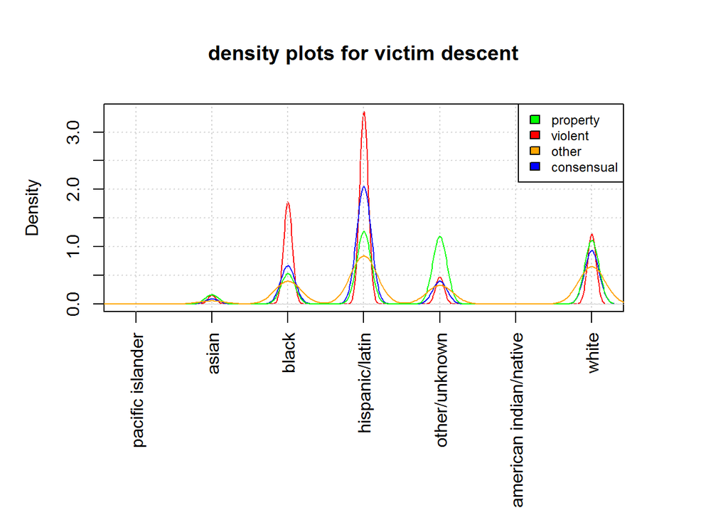

```r
> # quadruple density plot for victim.descent, from training dataset
> par(mar=c(10,5,5,5))
> plot(density(as.numeric(crimes$victim.descent[crimes$crime.type == 'violent'])), main='density plots for victim descent', col='red', xlab='', xaxt='n')
> grid()
> lines(density(as.numeric(crimes$victim.descent[crimes$crime.type == 'consensual'])), col='blue')
> lines(density(as.numeric(crimes$victim.descent[crimes$crime.type == 'property'])), col='green')
> lines(density(as.numeric(crimes$victim.descent[crimes$crime.type == 'other'])), col='orange')
> axis(1, labels=c('pacific islander', 'asian', 'black', 'hispanic/latin', 'other/unknown', 'american indian/native', 'white'), at=1:7, las=2)
> legend('topright', fill=c('green', 'red', 'orange', 'blue'), legend=c('property', 'violent', 'other', 'consensual'), cex=0.75)
```

Below are probabilities for victim descent categorized by the crime type.

```r
> nb.descent.info = nb.fit2$tables$victim.descent
> nb.descent.info
```

```
            victim.descent
Y            american indian/native        asian        black
  consensual           0.0006297229 0.0208595718 0.1605006297
  other                0.0003280167 0.0246832588 0.1745869039
  property             0.0005531203 0.0379601846 0.1246848367
  violent              0.0002800367 0.0217934427 0.2555691608
            victim.descent
Y            hispanic/latin other/unknown pacific islander        white
  consensual   0.4974023929  0.0954817380     0.0002361461 0.2248897985
  other        0.3700848743  0.1432613063     0.0003690188 0.2866866210
  property     0.2972284064  0.2774658794     0.0004148402 0.2616927325
  violent      0.4809602513  0.0677359309     0.0002141457 0.1734470319
```

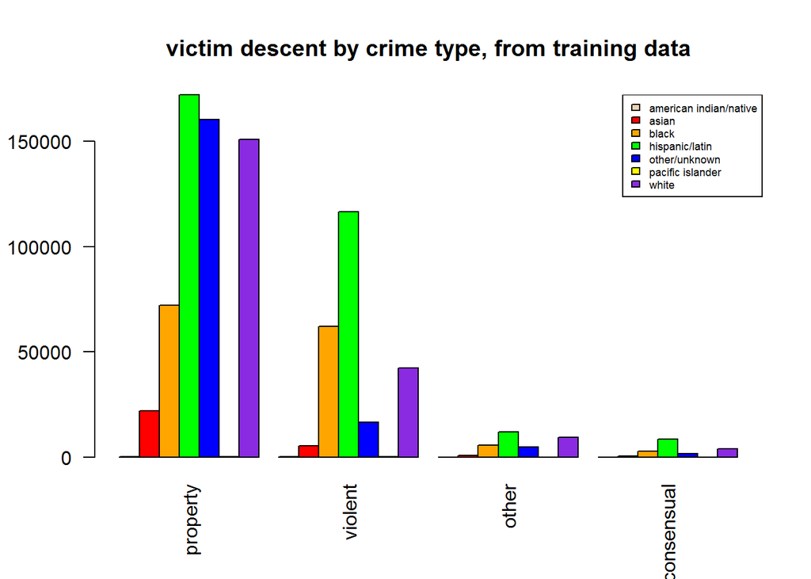

```r
> # side by side barplots for victim descent, frome training dataset
> colors = c('bisque2', 'red', 'orange', 'green', 'blue', 'yellow', 'blueviolet')
> property = table(crimes$victim.descent[crimes$crime.type == 'property'])
> violent = table(crimes$victim.descent[crimes$crime.type == 'violent'])
> other = table(crimes$victim.descent[crimes$crime.type == 'other'])
> consensual = table(crimes$victim.descent[crimes$crime.type == 'consensual'])
> tbls = cbind(property, violent, other, consensual)
> barplot(tbls, main='victim descent by crime type, from training data', col=colors, beside=T, las=2)
> legend('topright', fill=colors, legend=sort(unique(crimes$victim.descent)), cex=0.55)
```

Finally, the same values as above were estimated using the Naive Bayes classifier. Overall, the same patterns occur, where people of Hispanic/Latin descent were victims of most crimes.

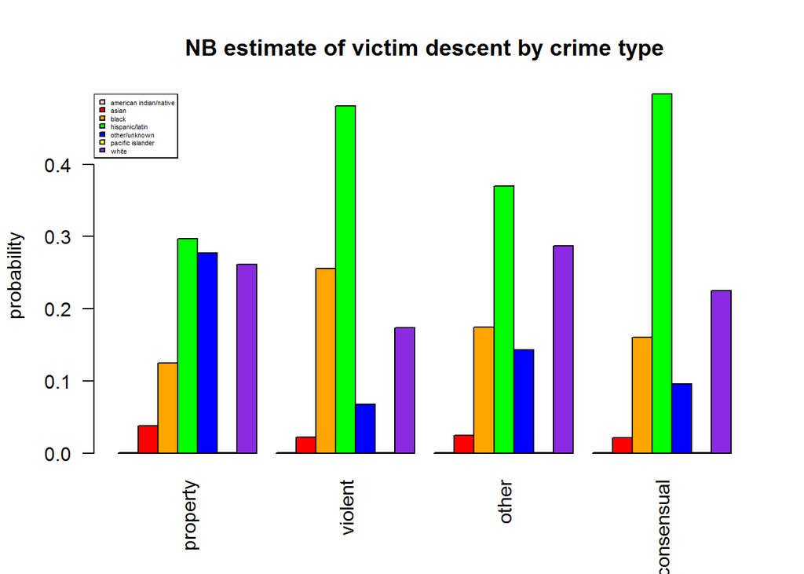

```r
> # side by side barplots for victim descent, from naive bayes
> property = nb.descent.info['property',]
> violent = nb.descent.info['violent',]
> other = nb.descent.info['other',]
> consensual = nb.descent.info['consensual',]
> tbls = cbind(property, violent, other, consensual)
> barplot(tbls, main='NB estimate of victim descent by crime type', col=colors, beside=T, las=2, ylab='probability')
> legend('topleft', fill=colors, legend=sort(unique(crimes$victim.descent)), cex=0.35)
```

## Conclusion

Our goal was to generate a model that would help us predict the type of crime that was committed based on the available data. Out of the three models that were generated, two of them gave us decent results. From our first model (classification tree), we learned that weapon type was going to be an important factor in generating a good model. Our second model (Naive Baye’s) also used weapon type as a predictor, but this time it was combined with the area in which the crime was committed. This model gave us a very similar result to our first model, but we felt that it was a bit more intuitive. In our last model (Naive Baye’s) we were interested to see if the demographics of the victim would be a good predictor for the type of crime that was committed. Unfortunately, the last model did not perform as well as our previous two models.

From the results of our models, we learned that one of the best predictors for what type of crime is committed, is the type of weapon that was involved. Before this, we believed that perhaps the demographics of the victim would have been a decent indicator of the type of crimes that are committed, we assumed that perhaps certain demographics would have been more susceptible to be the victims of certain crimes. It is important to note that this is only true for the City of Los Angeles for crimes committed during this decade. More data and analysis from other cities would be necessary in order to make any generalizations